# Statystyka w R

Magda G.

13 sierpnia 2018

## Statystyka opisowa

##### Funkcje statystyki opisowej w R

[output not shown]

W celu przedstawienia możliwości R użyjemy danych dostarczanych przez R - iris

```r
dane <- iris # Przypisanie danych do zmiennej
head(dane, 6)
```

```
  Sepal.Length Sepal.Width Petal.Length Petal.Width Species
1          5.1         3.5          1.4         0.2  setosa
2          4.9         3.0          1.4         0.2  setosa
3          4.7         3.2          1.3         0.2  setosa
4          4.6         3.1          1.5         0.2  setosa
5          5.0         3.6          1.4         0.2  setosa
6          5.4         3.9          1.7         0.4  setosa
```

#### Miary skupienia

Dla pojedynczej próby do określania tendencji centralnej danych służą średnia (wrażliwa na wartości odstające, mediana (bardziej ‘odporna’ alternatywa dla średniej) i moda (najczęstsza wartość w próbie)

```r
mean(dane$Sepal.Length) # średnia
```

```
[1] 5.843333
```

```r
median(dane$Sepal.Length) # mediana
```

```
[1] 5.8
```

```r
# install.packages("modeest")
require(modeest)
mfv(dane$Sepal.Length) # moda
```

```
[1] 5
```

#### Miary zmienności

Opisują rozproszenie wartości cechy w populacji/ próbie. Są miarą dyspersji danych.

1. minimum, maksimium i zakres danych.

###### Używane rzadko ponieważ są bardzo wrażliwe na dane odstające.

```r
min(dane$Sepal.Length) # minimum
```

```
[1] 4.3
```

```r
max(dane$Sepal.Length) # maksimum
```

```
[1] 7.9
```

```r
range(dane$Sepal.Length) # zakres danych
```

```
[1] 4.3 7.9
```

2. Kwantyle

###### Kwartyle dzielą dane na 4 zakresy. Rozstęp ćwiartkowy (różnica pomiędzy 1 i 3 kwartylem w pewnych sytuacjach zastępuje odchylenie standardowe. Kwartyle są szczególnymi przypadkami kwantyli.

quantile(x, probs = seq(0, 1, 0.25))

x: wektor liczbowy, w którym określamy kwantyle probs: liczbowy wektor prawdopodobieństw o zakresie [0,1].

###### Rozstęp ćwiartkowy używany jest dość często, szczególnie w połączeniu z medianą. Są mało wrażliwe na wartości odstające.

```r
quantile(dane$Sepal.Length) # standardowo funkja zwraca kwartle
```

```
  0%  25%  50%  75% 100%
 4.3  5.1  5.8  6.4  7.9
```

```r
quantile(dane$Sepal.Length, seq(0, 1, 0.1)) # funkcja zwróci decyle
```

```
  0%  10%  20%  30%  40%  50%  60%  70%  80%  90% 100%
4.30 4.80 5.00 5.27 5.60 5.80 6.10 6.30 6.52 6.90 7.90
```

```r
IQR(dane$Sepal.Length) # zwraca zakres ćwiartkowy
```

```
[1] 1.3
```

3. Wariancja i odchylenie standardowe

###### Wariancja to średni kwadrat odchyleń od średniej. Używana jest bardzo rzadko, głównie w kalkulacjach, ponieważ nie ma tych samych jednostek, co próba. Odchylenie standardowe jest pierwiastkiem z wariancji. Jest miarą przecietnego odchylenia wartości w próbie od średniej. Używane jest, gdy miarą tendencji centralnej jest średnia.

```r
var(dane$Sepal.Length) # wariancja
```

```
[1] 0.6856935
```

```r
sd(dane$Sepal.Length) # odchylenie standardowe
```

```
[1] 0.8280661
```

4. Odchylenie medianowe (MAD)

###### Mierzy odchylenie wartości od wyznaczonej mediany. Używana dość rzadko, ale jest mało wrażliwa na wartości odstające.

```r
median(dane$Sepal.Length)
```

```
[1] 5.8
```

```r
mad(dane$Sepal.Length)
```

```
[1] 1.03782
```

#### Funkcja **summary()**

###### Służy do policzenia statystyki opisowej 1 zmiennej, albo całej ramki danych

```r
summary(dane$Sepal.Length) # podsumowanie statystyki opisowej zmiennej
```

```
   Min. 1st Qu.  Median    Mean 3rd Qu.    Max.
  4.300   5.100   5.800   5.843   6.400   7.900
```

```r
summary(dane, digits = 2) # podsumowanie statystyki opisowej ramki danych
```

```
  Sepal.Length  Sepal.Width   Petal.Length  Petal.Width        Species
 Min.   :4.3   Min.   :2.0   Min.   :1.0   Min.   :0.1   setosa    :50
 1st Qu.:5.1   1st Qu.:2.8   1st Qu.:1.6   1st Qu.:0.3   versicolor:50
 Median :5.8   Median :3.0   Median :4.3   Median :1.3   virginica :50
 Mean   :5.8   Mean   :3.1   Mean   :3.8   Mean   :1.2
 3rd Qu.:6.4   3rd Qu.:3.3   3rd Qu.:5.1   3rd Qu.:1.8
 Max.   :7.9   Max.   :4.4   Max.   :6.9   Max.   :2.5
```

#### Funkcja **sapply()**

###### Korzystając z funkcji `sapply()` możemy zastosować określoną funkcję do listy wektorów. Przykładowo dla każdej kolumny ramki danych możemy policzyć średnią, odchylenie stnadardowe, wariancję, minimum, kwantyle i tp.

```r
sapply(dane[, -5], mean) # liczy średnią z kolumn
```

```
Sepal.Length  Sepal.Width Petal.Length  Petal.Width
    5.843333     3.057333     3.758000     1.199333
```

```r
sapply(dane[, -5], quantile) # liczy kwartyle dla kolumn
```

```
     Sepal.Length Sepal.Width Petal.Length Petal.Width
0%            4.3         2.0         1.00         0.1
25%           5.1         2.8         1.60         0.3
50%           5.8         3.0         4.35         1.3
75%           6.4         3.3         5.10         1.8
100%          7.9         4.4         6.90         2.5
```

#### Funkcja **stat.desc()**

###### Funkcja `stat.desc()` dostarcza kilka innych statystych niż wcześniej wspomniane. Liczy również błąd standardowy średniej, przedział ufności dla średniej (standardowo dla p = 0,95) i współczynnik wariancji (odchylenie standardowe podzielone przez średnią)

```r
# install.packages("pastecs")
library(pastecs)
res <- stat.desc(dane[, -5])
round(res, 2)
```

```
             Sepal.Length Sepal.Width Petal.Length Petal.Width
nbr.val            150.00      150.00       150.00      150.00
nbr.null             0.00        0.00         0.00        0.00
nbr.na               0.00        0.00         0.00        0.00
min                  4.30        2.00         1.00        0.10
max                  7.90        4.40         6.90        2.50
range                3.60        2.40         5.90        2.40
sum                876.50      458.60       563.70      179.90
median               5.80        3.00         4.35        1.30
mean                 5.84        3.06         3.76        1.20
SE.mean              0.07        0.04         0.14        0.06
CI.mean.0.95         0.13        0.07         0.28        0.12
var                  0.69        0.19         3.12        0.58
std.dev              0.83        0.44         1.77        0.76
coef.var             0.14        0.14         0.47        0.64
```

Brakujące wartości NA w danych moga zaburzyć działanie niektórych funkcji, dlatego często stosuje się parametr na.rm = TRUE, który informuje funkcje, że ma usunąć wartości NA, przed wykonaniem obliczeń

```r
mean(dane$Sepal.Length, na.rm = TRUE)
```

```
[1] 5.843333
```

#### Statystyka opisowa danych podzielonych na kategorie

Liczenie parametrów dla grupdanych możliwe jest dzięki funkcjom `group_by()` i `summarise()` znajdujących sie w pakiecie `dplyr`

```r
# install.packages("dplyr")
library(dplyr)
group_by(dane, Species) %>% # Podział danych na gatunki
summarise(
  count = n(), # zliczenie danych w kazdej z grup
  mean = mean(Sepal.Length, na.rm = TRUE), # średnia  w grupach
  sd = sd(Sepal.Length, na.rm = TRUE) # odchylenie standardowe w grupach
  ) # wartości dotyczą długości płatków
```

```
# A tibble: 3 x 4
  Species    count  mean    sd
  <fct>      <int> <dbl> <dbl>
1 setosa        50  5.01 0.352
2 versicolor    50  5.94 0.516
3 virginica     50  6.59 0.636
```

Operator %>% służy do tworzenia ciągów analiz. Jest to mozliwe dzięki pakietowi dplyr, ponieważ R wymaga zapisywania danych cząstkowych i wykorzystywania ich na kolejnych etapach analizy. Zastosowanie %>% usprawnia analizę danych w R oraz upodabnia funkcjonalnie R do innych języków peogramowania np.: bash czy Python.

### Graficzne przedstawienie parametrów próby

Będziemy pracować przede wszystkim korzystając z funkcji pakietu `ggpubr` oraz danych `iris` wprowadzonych wcześniej jako `"dane"`

```r
# Instalacja ggpubr - jeśli wymagana `od'hash'uj` linijki
# if(!require(devtools)) install.packages("devtools")
# devtools::install_github("kassambara/ggpubr")
# lub instalacja z CRAN
# install.packages("ggpubr")

library(ggpubr)
```

Kilka typów wykresów o różnych zastosowaniach

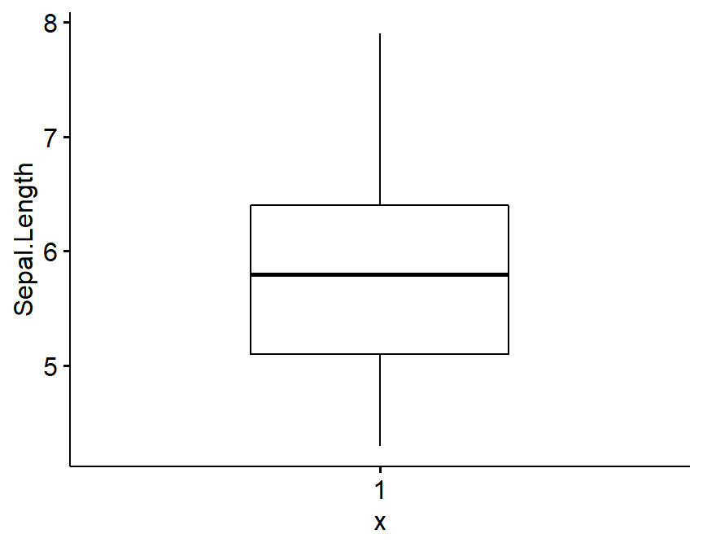

```r
# Wykres pudełkowy - pokazuje dystrybucję danych
ggboxplot(dane, y = "Sepal.Length", width = 0.5)
```

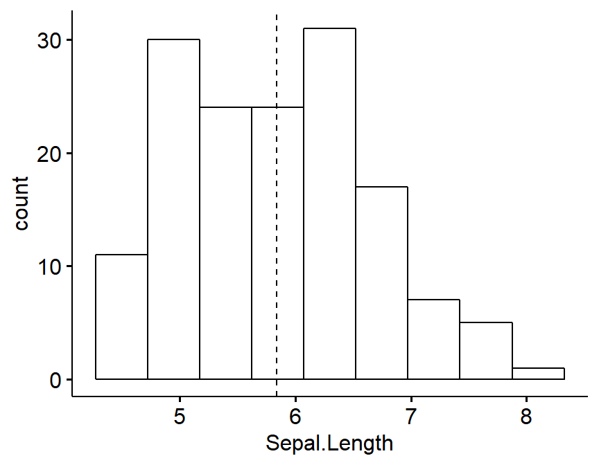

```r
# Histogram - pokazuje liczbe obserwacji w danym zakresie wartości (bin)
# dodatkowo na wykresie zaznzaczono średnią
gghistogram(dane, x = "Sepal.Length", bins = 9, add = "mean")
```

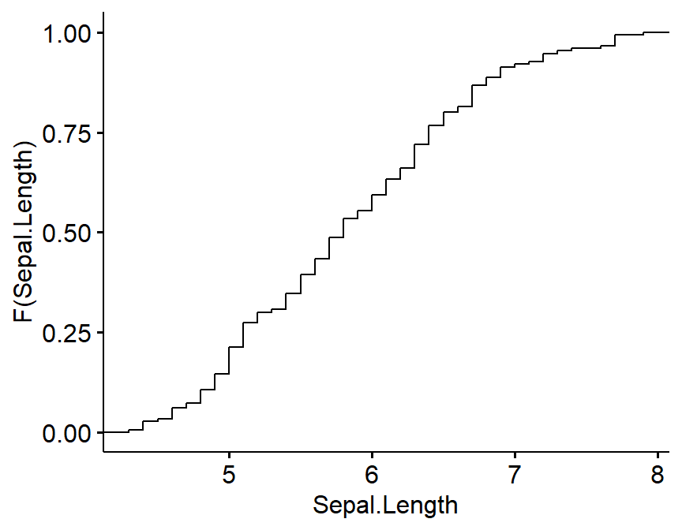

```r
#ECDF (Empirical cumulative distribution function) - frakcja danych o wartości mniejszej niż x lub równej
ggecdf(dane, x = "Sepal.Length")
```

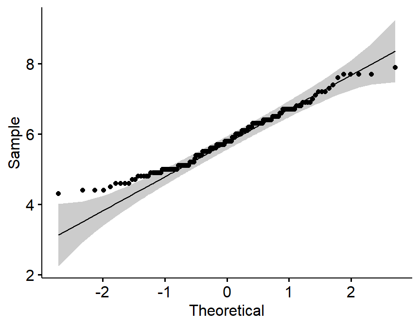

```r
# Q-Q plots - służy do sprawdzenia czy dane mają rozkład normalny
ggqqplot(dane, x = "Sepal.Length")
```

#### Graficzne przedstawienie danych pogrupowanych na kategorie

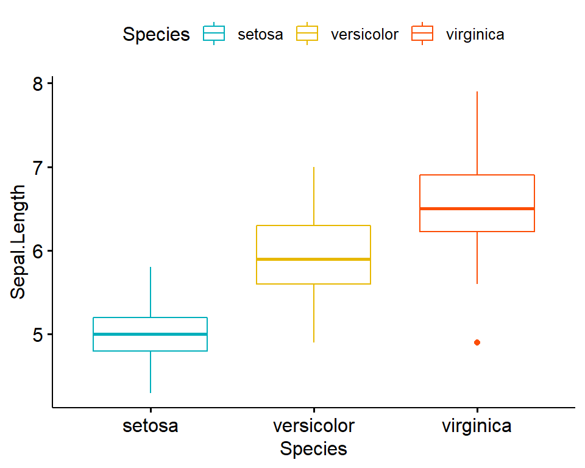

```r
library("ggpubr")
# Wykres pudełkowy z podziałem na gatunki oraz zależnym od gatunku kolorem
ggboxplot(dane, x = "Species", y = "Sepal.Length",
          color = "Species",
          palette = c("#00AFBB", "#E7B800", "#FC4E07"))
```

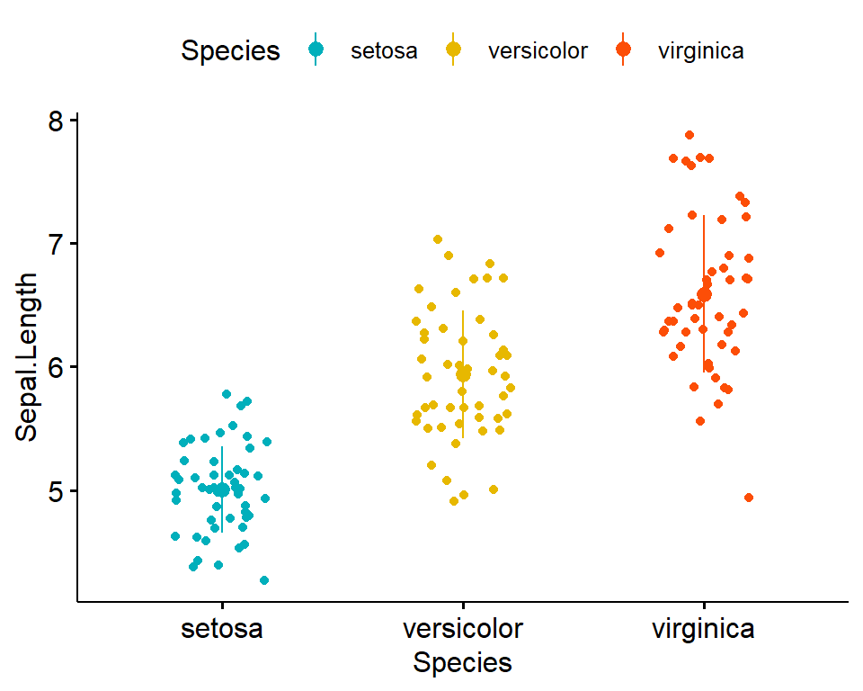

```r
# Stripchart z podziałem na gatunki oraz zależnym od gatunku kolorem
ggstripchart(dane, x = "Species", y = "Sepal.Length",
          color = "Species",
          palette = c("#00AFBB", "#E7B800", "#FC4E07"),
          add = "mean_sd")
```

Kiedy dancyh w grupach jest mało lepiej jest używać stripchart niż wykresów pudełkowych.

### Tabele częstości/ kontygencji

Służą do przedstawiania liczebności danych kategorycznych. W R do ich utworzenia służy polecenie `table()`

Do analizy posłużą dane “HairEyeColor” zawierające dane o płci, kolorze włosów i oczu 592 studentów

```r
# Utworzenie ramki danych
df <- as.data.frame(HairEyeColor)
kolor_oczu_wlosow <- df[rep(row.names(df), df$Freq), 1:3]
# Przeksztalca dane tworząc liczbę wierszy każdej z kombinacji kategorii
# równą podanej w 4 kolumnie (df$Freq) częstotliwości
rownames(kolor_oczu_wlosow) <- 1:nrow(kolor_oczu_wlosow)
head(kolor_oczu_wlosow)
```

```
   Hair   Eye  Sex
1 Black Brown Male
2 Black Brown Male
3 Black Brown Male
4 Black Brown Male
5 Black Brown Male
6 Black Brown Male
```

```r
# Utworzenie czynników (factor) kategorii
Hair <- kolor_oczu_wlosow$Hair
Eye <- kolor_oczu_wlosow$Eye
levels(Eye) # Poziomy czynnika 'Eye' kolor oczu
```

```
[1] "Brown" "Blue"  "Hazel" "Green"
```

```r
levels(Hair) # Poziomy czynnika 'Hair' kolor włosów
```

```
[1] "Black" "Brown" "Red"   "Blond"
```

```r
# Prosta dystrybucja częstotliwości dla 1 zmiennej - koloru włosów
table(Hair)
```

```
Hair
Black Brown   Red Blond
  108   286    71   127
```

```r
# Prosta dystrybucja częstotliwości dla 1 zmiennej - koloru oczu
table(Eye)
```

```
Eye
Brown  Blue Hazel Green
  220   215    93    64
```

```r
# 2-kierunkowa tabela dystrybucji częstotliwości dla kombinacji obu zmiennych
table(Hair, Eye)
```

```
       Eye
Hair    Brown Blue Hazel Green
  Black    68   20    15     5
  Brown   119   84    54    29
  Red      26   17    14    14
  Blond     7   94    10    16
```

```r
xtabs(~ Hair + Eye, data = kolor_oczu_wlosow) # Tworzy tabelę krzyżową na podstawie podanej formuły
```

```
       Eye
Hair    Brown Blue Hazel Green
  Black    68   20    15     5
  Brown   119   84    54    29
  Red      26   17    14    14
  Blond     7   94    10    16
```

```r
# Wprowadzamy dodatkowo podział na kobiety i mężczyzn (3 zmienna)
xtabs(~Hair + Eye + Sex, data = kolor_oczu_wlosow)
```

```
, , Sex = Male

       Eye
Hair    Brown Blue Hazel Green
  Black    32   11    10     3
  Brown    53   50    25    15
  Red      10   10     7     7
  Blond     3   30     5     8

, , Sex = Female

       Eye
Hair    Brown Blue Hazel Green
  Black    36    9     5     2
  Brown    66   34    29    14
  Red      16    7     7     7
  Blond     4   64     5     8
```

```r
# Funkcja ftable() tworzy spłaszczoną (ładniejszą) wersję tabeli krzyżowej
ftable(Sex + Hair ~ Eye, data = kolor_oczu_wlosow)
```

```
      Sex   Male                 Female
      Hair Black Brown Red Blond  Black Brown Red Blond
Eye
Brown         32    53  10     3     36    66  16     4
Blue          11    50  10    30      9    34   7    64
Hazel         10    25   7     5      5    29   7     5
Green          3    15   7     8      2    14   7     8
```

Możliwe jest również policznie sum w kolumnach i rzędach oraz relatywnej częstości (stosunek wartości w danej pozycji tabeli do zliczonej wartości w kolumnie lub rzędzie). Funkcja `margin.table()` zlicza wartości w kulumach/ rzędach, a `prop.table()` wylicza częstości relatywne.

###### **Format funkcji:**

margin.table(x, margin = NULL)

prop.table(x, margin = NULL)

x: utworzona tabela margin: indeks (1 dla rzędów and 2 dla kolumn)

```r
# Oblicznie wartości brzegowych
oba.tbl <- table(Hair, Eye) # Tabela krzyżowa dla obu wartości

# Wartości brzegowe rzdów
margin.table(oba.tbl, 1) # Wartości brzegowe rzdów
```

```
Hair
Black Brown   Red Blond
  108   286    71   127
```

```r
margin.table(oba.tbl, 2) # Wartości brzegowe kolumn
```

```
Eye
Brown  Blue Hazel Green
  220   215    93    64
```

```r
prop.table(oba.tbl, 1) # Częstości w odniesieniu do wartości brzegowych rzędów
```

```
       Eye
Hair         Brown       Blue      Hazel      Green
  Black 0.62962963 0.18518519 0.13888889 0.04629630
  Brown 0.41608392 0.29370629 0.18881119 0.10139860
  Red   0.36619718 0.23943662 0.19718310 0.19718310
  Blond 0.05511811 0.74015748 0.07874016 0.12598425
```

```r
round(prop.table(oba.tbl, 1), 3)*100 # Podanie wartości w procentach
```

```
       Eye
Hair    Brown Blue Hazel Green
  Black  63.0 18.5  13.9   4.6
  Brown  41.6 29.4  18.9  10.1
  Red    36.6 23.9  19.7  19.7
  Blond   5.5 74.0   7.9  12.6
```

```r
# funkcja round() zaokrągla wartości do podanej liczby miejsc po przcinku
```

#### Graficzne przedstawienie wyników

```r
# Przekonwertowanie tabeli na ramkę danych
dfh <- as.data.frame(table(Hair))
dfh
```

```
   Hair Freq
1 Black  108
2 Brown  286
3   Red   71
4 Blond  127
```

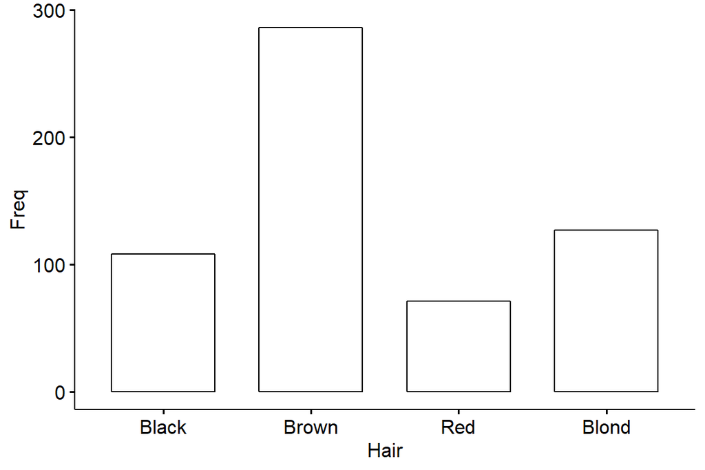

```r
# Utworzenie wykresu słupkowego
library(ggpubr) # ładowanie pakietu ggpubr
# wykorzystanie możliwości pakietu do tworzenia wykresów bazującego na uproszczonym działaniu pakietu ggplot2
ggbarplot(dfh, x = "Hair", y = "Freq")
```

```r
dfb <- as.data.frame(xtabs(~ Hair + Eye, data = kolor_oczu_wlosow))
head(dfb)
```

```
   Hair   Eye Freq
1 Black Brown   68
2 Brown Brown  119
3   Red Brown   26
4 Blond Brown    7
5 Black  Blue   20
6 Brown  Blue   84
```

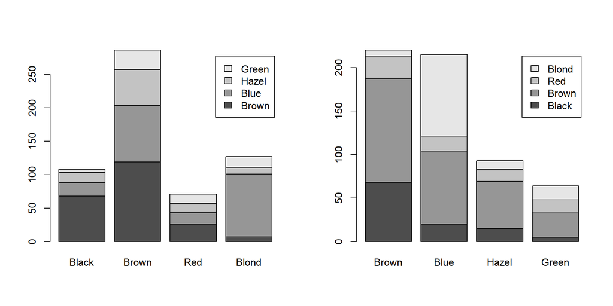

```r
# Twrzenie wykresu słupkowego 1 zmiennej z uwzględnieniem 2 zmiennej
par(mfrow=c(1,2))
barplot(xtabs(~ Eye + Hair, data = kolor_oczu_wlosow), legend = levels(Eye))
barplot(xtabs(~ Hair + Eye, data = kolor_oczu_wlosow), legend = levels(Hair))
```

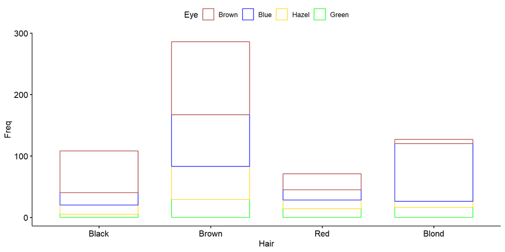

```r
# library(ggpubr) - usunąć #, jesli w danej sesji nie był używany ten pakiet
ggbarplot(dfb, x = "Hair", y = "Freq",
          color = "Eye",
          palette = c("brown", "blue", "gold", "green"))
```

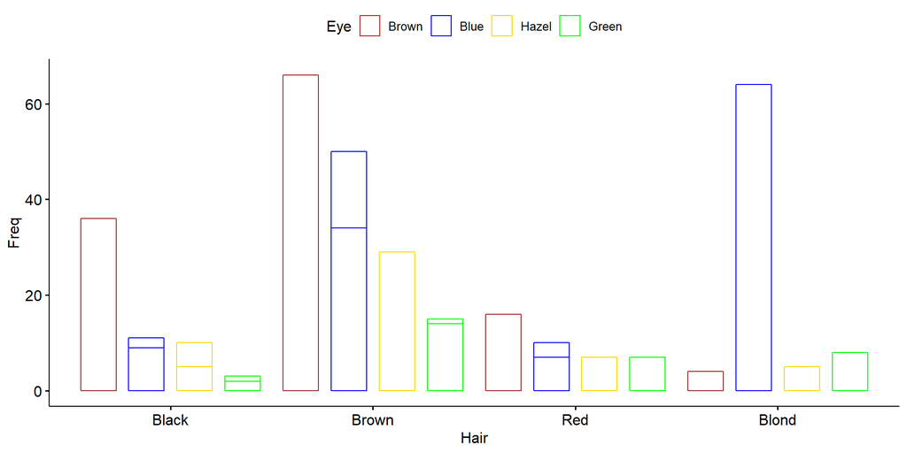

```r
# Wersja z osobnymi słupkami dla częstotliwości
ggbarplot(df, x = "Hair", y = "Freq",
          color = "Eye", position = position_dodge(),
          palette = c("brown", "blue", "gold", "green"))
```